# Assignment 3

Author

Arianna Hernandez

# Text Mining

A new dataset has been added to the data science data repository https://github.com/USCbiostats/data-science-data/tree/master/03_pubmed. The dataset contains 3,241 abstracts from articles collected via 5 PubMed searches. The search terms are listed in the second column, term and these will serve as the “documents.” Your job is to analyse these abstracts to find interesting insights.

```r
# read in the data and check for number of observations and variables
pub<- read.csv('pubmed.csv')
str(pub)
```

```
'data.frame':   3241 obs. of  2 variables:
 $ abstract: chr  "Background and aims: Many patients with coronavirus disease 2019 (COVID-19) have underlying cardiovascular (CV)"| __truncated__ "Introduction: Contradictory data have been reported on the incidence of stroke in patients with COVID-19 and th"| __truncated__ "This article aims at co…
 $ term    : chr  "covid" "covid" "covid" "covid" ...
```

### 1. Tokenize the abstracts and count the number of each token. Do you see anything interesting? Does removing stop words change what tokens appear as the most frequent? What are the 5 most common tokens for each search term after removing stopwords?

```r
#first, we look at the top words in the "abstract" category
pub %>%
unnest_tokens(token, abstract) %>%
  count(token, sort = TRUE) %>%
  top_n(10, n)%>%
  kable(caption = "Top 10 Tokens", align = "c")
```

Top 10 Tokens

| token | n |
| --- | --- |
| the | 28126 |
| of | 24760 |
| and | 19993 |
| in | 14653 |
| to | 10920 |
| a | 8245 |
| with | 8038 |
| covid | 7275 |
| 19 | 7080 |
| is | 5649 |

```r
#we also want to see what the search terms are
pub %>%
  count(term, sort = TRUE) %>%
  kable(caption = "Abstract Search Terms", align = "c")
```

Abstract Search Terms

| term | n |
| --- | --- |
| covid | 981 |
| prostate cancer | 787 |
| preeclampsia | 780 |
| cystic fibrosis | 376 |
| meningitis | 317 |

```r
#first we look at the most frequent overall tokens
pub %>%
  unnest_tokens(token, abstract) %>%
  anti_join(stop_words, by = c("token" = "word")) %>%
  count(token,sort = TRUE) %>%
  top_n(10, n)%>%
  kable(caption = "Top 10 Tokens Without Stop Words", align = "c")
```

Top 10 Tokens Without Stop Words

| token | n |
| --- | --- |
| covid | 7275 |
| 19 | 7080 |
| patients | 4674 |
| cancer | 3999 |
| prostate | 3832 |
| disease | 2574 |
| pre | 2165 |
| eclampsia | 2005 |
| preeclampsia | 1863 |
| treatment | 1841 |

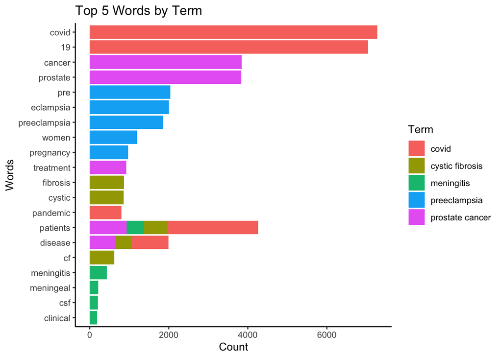

```r
# then, we look at the top 5 per search term
top5<- pub %>%
  unnest_tokens(token, abstract) %>%
  anti_join(stop_words, by = c("token" = "word")) %>%
  group_by(term) %>%
  count(token,sort = TRUE) %>%
  top_n(5, n)%>%
  arrange(term, desc(n))

top5 %>%
  ggplot(aes(n, fct_reorder(token, n), fill = term)) +
  geom_col()+
  labs(title = "Top 5 Words by Term",
       x = "Count",
       y = "Words",
       fill = "Term")+
  theme_classic()
```

```r
top5 %>%
  kable(caption = "Top 5 Words by Term", align = "c")
```

Top 5 Words by Term

| term | token | n |
| --- | --- | --- |
| covid | covid | 7275 |
| covid | 19 | 7035 |
| covid | patients | 2293 |
| covid | disease | 943 |
| covid | pandemic | 800 |
| cystic fibrosis | fibrosis | 867 |
| cystic fibrosis | cystic | 862 |
| cystic fibrosis | cf | 625 |
| cystic fibrosis | patients | 586 |
| cystic fibrosis | disease | 400 |
| meningitis | patients | 446 |
| meningitis | meningitis | 429 |
| meningitis | meningeal | 219 |
| meningitis | csf | 206 |
| meningitis | clinical | 187 |
| preeclampsia | pre | 2038 |
| preeclampsia | eclampsia | 2005 |
| preeclampsia | preeclampsia | 1863 |
| preeclampsia | women | 1196 |
| preeclampsia | pregnancy | 969 |
| prostate cancer | cancer | 3840 |
| prostate cancer | prostate | 3832 |
| prostate cancer | patients | 934 |
| prostate cancer | treatment | 926 |
| prostate cancer | disease | 652 |

Removing the stop words, the top tokens change drastically and give us a more clear image about the content of these abstracts. Additionally, the top 5 words for each search term make sense for the context they are being used in.

### 2. Tokenize the abstracts into bigrams. Find the 10 most common bigrams and visualize them with ggplot2.

```r
#top 10 bigrams
bg<-pub %>%
  unnest_ngrams(ngram, abstract, n = 2) %>%
  count(ngram,sort = TRUE) %>%
  top_n(10, n)

bg %>%
  kable(caption = "10 most-common Bigrams", align = "c")
```

10 most-common Bigrams

| ngram | n |
| --- | --- |
| covid 19 | 6969 |
| of the | 3883 |
| in the | 3418 |
| prostate cancer | 3222 |
| pre eclampsia | 1854 |
| patients with | 1587 |
| of covid | 1519 |
| and the | 1154 |
| to the | 1061 |
| of prostate | 870 |

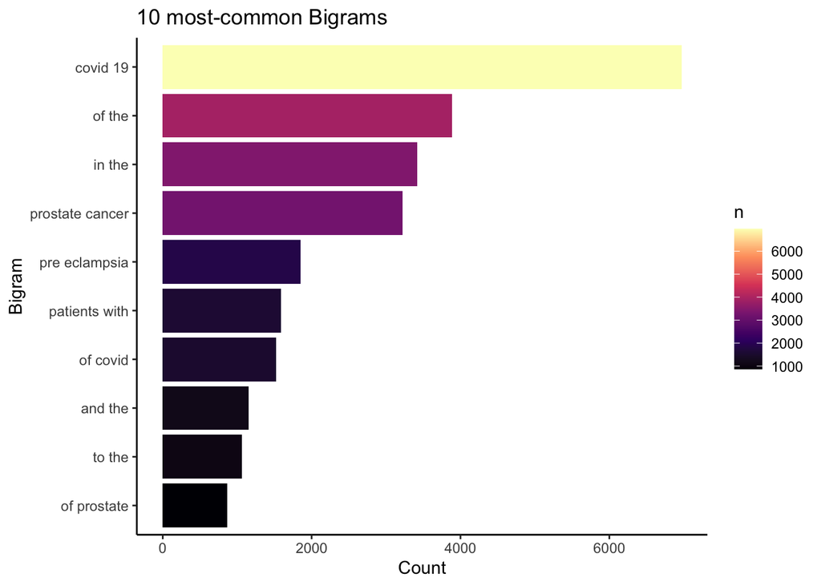

```r
bg %>%
  ggplot(aes(n, fct_reorder(ngram, n), fill = n)) +
  scale_fill_viridis_c(option = "magma") +
  geom_col()+
  labs(title = "10 most-common Bigrams",
       x = "Count",
       y = "Bigram") +
  theme_classic()
```

The top 10 bigrams mention some of the term words, but because of the many stop words, these don’t share much more about the content of the abstracts that you couldn’t get from the search term. For this, I want to look at the top five bigrams by term.

```r
#further analysis of bigrams by term
#here we look at the top 10 bigrams by term
bgt<-pub %>%
  unnest_ngrams(ngram, abstract, n = 2) %>%
  group_by(term) %>%
  count(ngram,sort = TRUE) %>%
  top_n(5, n) %>%
  arrange(term, desc(n))

bgt %>%
  kable(caption = "5 most-common Bigrams by term", align = "c")
```

5 most-common Bigrams by term

| term | ngram | n |
| --- | --- | --- |
| covid | covid 19 | 6969 |
| covid | of covid | 1519 |
| covid | of the | 1119 |
| covid | in the | 943 |
| covid | patients with | 718 |
| cystic fibrosis | cystic fibrosis | 859 |
| cystic fibrosis | of the | 452 |
| cystic fibrosis | in the | 319 |
| cystic fibrosis | with cystic | 207 |
| cystic fibrosis | patients with | 196 |
| meningitis | of the | 527 |
| meningitis | in the | 332 |
| meningitis | patients with | 163 |
| meningitis | and the | 97 |
| meningitis | cerebrospinal fluid | 88 |
| preeclampsia | pre eclampsia | 1854 |
| preeclampsia | in the | 1004 |
| preeclampsia | of the | 995 |
| preeclampsia | of pre | 588 |
| preeclampsia | of preeclampsia | 578 |
| prostate cancer | prostate cancer | 3222 |
| prostate cancer | of prostate | 870 |
| prostate cancer | in the | 820 |
| prostate cancer | of the | 790 |
| prostate cancer | patients with | 340 |

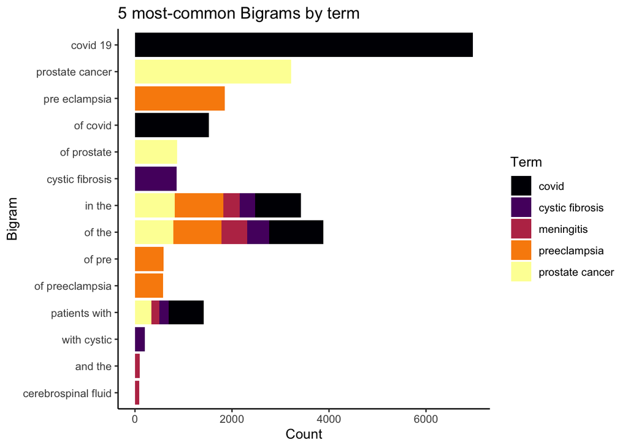

```r
bgt %>%
  ggplot(aes(n, fct_reorder(ngram, n), fill = term)) +
  scale_fill_viridis_d(option = "inferno") +
  geom_col()+
  labs(title = "5 most-common Bigrams by term",
       x = "Count",
       y = "Bigram",
       fill = "Term")+
  theme_classic()
```

We can see more meaningful content from the search term ‘meningitis’, where they mention cerebrospinal fluid and thus share more about what this is about. However, the other terms don’t offer better insight to the contents of these abstracts.

### 3. Calculate the TF-IDF value for each word-search term combination (here you want the search term to be the “document”). What are the 5 tokens from each search term with the highest TF-IDF value? How are the results different from the answers you got in question 1?

```r
#TF-IDF values for every word-search term combination
ti<-pub %>%
  unnest_tokens(word, abstract) %>%
  count(word, term) %>%
  bind_tf_idf(word, term, n) %>%
  arrange(desc(tf_idf))

head(ti) %>%
  kable(caption = "Top TF-IDF values for every word-search term combination", align = "c")
```

Top TF-IDF values for every word-search term combination

| word | term | n | tf | idf | tf_idf |
| --- | --- | --- | --- | --- | --- |
| covid | covid | 7275 | 0.0371050 | 1.6094379 | 0.0597183 |
| prostate | prostate cancer | 3832 | 0.0311890 | 1.6094379 | 0.0501967 |
| eclampsia | preeclampsia | 2005 | 0.0142784 | 1.6094379 | 0.0229802 |
| preeclampsia | preeclampsia | 1863 | 0.0132672 | 1.6094379 | 0.0213527 |
| meningitis | meningitis | 429 | 0.0091942 | 1.6094379 | 0.0147974 |
| cf | cystic fibrosis | 625 | 0.0127188 | 0.9162907 | 0.0116541 |

The highest TF-IDF for word-term combinations are all identifying words for the search term used. It is different from question one in that it doesn’t have words that are generally related to illness, such as “treatment”, “disease”, and “patients”.

```r
ti %>%
  group_by(term) %>%
  top_n(5, tf_idf) %>%
  arrange(term) %>%
  kable(caption = "Top TF-IDF Values For All Word-Term Combinations", align = "c" )
```

Top TF-IDF Values For All Word-Term Combinations

| word | term | n | tf | idf | tf_idf |
| --- | --- | --- | --- | --- | --- |
| covid | covid | 7275 | 0.0371050 | 1.6094379 | 0.0597183 |
| pandemic | covid | 800 | 0.0040803 | 1.6094379 | 0.0065670 |
| coronavirus | covid | 647 | 0.0032999 | 1.6094379 | 0.0053110 |
| sars | covid | 372 | 0.0018973 | 1.6094379 | 0.0030536 |
| cov | covid | 334 | 0.0017035 | 1.6094379 | 0.0027417 |
| cf | cystic fibrosis | 625 | 0.0127188 | 0.9162907 | 0.0116541 |
| fibrosis | cystic fibrosis | 867 | 0.0176435 | 0.5108256 | 0.0090127 |
| cystic | cystic fibrosis | 862 | 0.0175417 | 0.5108256 | 0.0089608 |
| cftr | cystic fibrosis | 86 | 0.0017501 | 1.6094379 | 0.0028167 |
| sweat | cystic fibrosis | 83 | 0.0016891 | 1.6094379 | 0.0027184 |
| meningitis | meningitis | 429 | 0.0091942 | 1.6094379 | 0.0147974 |
| meningeal | meningitis | 219 | 0.0046935 | 1.6094379 | 0.0075539 |
| pachymeningitis | meningitis | 149 | 0.0031933 | 1.6094379 | 0.0051394 |
| csf | meningitis | 206 | 0.0044149 | 0.9162907 | 0.0040453 |
| meninges | meningitis | 106 | 0.0022718 | 1.6094379 | 0.0036562 |
| eclampsia | preeclampsia | 2005 | 0.0142784 | 1.6094379 | 0.0229802 |
| preeclampsia | preeclampsia | 1863 | 0.0132672 | 1.6094379 | 0.0213527 |
| pregnancy | preeclampsia | 969 | 0.0069006 | 0.5108256 | 0.0035250 |
| maternal | preeclampsia | 797 | 0.0056757 | 0.5108256 | 0.0028993 |
| gestational | preeclampsia | 191 | 0.0013602 | 1.6094379 | 0.0021891 |
| prostate | prostate cancer | 3832 | 0.0311890 | 1.6094379 | 0.0501967 |
| androgen | prostate cancer | 305 | 0.0024824 | 1.6094379 | 0.0039953 |
| psa | prostate cancer | 282 | 0.0022952 | 1.6094379 | 0.0036940 |
| prostatectomy | prostate cancer | 215 | 0.0017499 | 1.6094379 | 0.0028164 |
| castration | prostate cancer | 148 | 0.0012046 | 1.6094379 | 0.0019387 |

In question 1, we had some keywords for all the term-word combinations. However, many of them contained generic illness-related words, such as “patients” and “disease”–that while they could be important for context–they are not necessary if we already know that these terms refer to different diseases.The top five words for each word-term combinations based on TF-IDF score all contain illness-specific words that can help give us a better understanding of our research. For example, ‘cftr’ which stands for Cystic Fibrosis Transmembrane Conductance Regulator for cystic fibrosis, or ‘prostatectomy’ and ‘castration’ for prostate cancer. Overall, I believe these are a better reference point than just their counts in the abstracts.

# Sentiment Analysis

### 1. Perform a sentiment analysis using the NRC lexicon. What is the most common sentiment for each search term? What if you remove “positive” and “negative” from the list?

```r
#citation for the NRC lexicon: Saif M. Mohammad and Peter Turney. (2013), ``Crowdsourcing a Word-Emotion Association Lexicon.'' Computational Intelligence, 29(3): 436-465.
#most common sentiments for each search term
pub %>%
  unnest_tokens(word, abstract) %>%
  inner_join(get_sentiments("nrc")) %>%
  group_by(term) %>%
  count(sentiment, sort = TRUE) %>%
  arrange(term) %>%
  slice_max(n, n = 1) %>%
  kable(caption = "Most Common Sentiment for Each Search Term",
        align = "c" )
```

Most Common Sentiment for Each Search Term

| term | sentiment | n |
| --- | --- | --- |
| covid | positive | 9874 |
| cystic fibrosis | positive | 2747 |
| meningitis | negative | 2109 |
| preeclampsia | positive | 8014 |
| prostate cancer | negative | 8918 |

```r
#Removing "positive" and "negative" sentiments from the list

pub %>%
  unnest_tokens(word, abstract) %>%
  inner_join(get_sentiments("nrc")) %>%
  group_by(term) %>%
  count(sentiment, sort = TRUE) %>%
  arrange(term, desc(n)) %>%
  filter(!(sentiment %in% c("positive", "negative"))) %>%
  slice_max(n, n = 1, with_ties = FALSE) %>%
  kable(caption = "Most Common Sentiment for Each Search Term Without Positive or Negative", align = "c")
```

Most Common Sentiment for Each Search Term Without Positive or Negative

| term | sentiment | n |
| --- | --- | --- |
| covid | fear | 7730 |
| cystic fibrosis | disgust | 1714 |
| meningitis | fear | 1510 |
| preeclampsia | anticipation | 4780 |
| prostate cancer | fear | 8118 |

For covid, cystic fibrosis, and preclampsia–the top sentiments are positive, followed by fear, disgust and anticipation. For meningitis and prostate cancer, the top sentiments are negative–followed by fear.

### 2. Now perform a sentiment analysis using the AFINN lexicon to get an average positivity score for each abstract (hint: you may want to create a variable that indexes, or counts, the abstracts). Create a visualization that shows these scores grouped by search term. Are any search terms noticeably different from the others?

```r
# citation for the AFINN lexicon: http://www2.imm.dtu.dk/pubdb/views/publication_details.php?id=6010
#first we create a variable that counts the abstracts and assigns an average positivity score to it
count<- pub %>%
      mutate(id = row_number())  %>%
      unnest_tokens(word, abstract)  %>%
      inner_join(get_sentiments('afinn'), by = "word")  %>%
      group_by(id, term)  %>%
      summarise(avg = mean(value, na.rm = TRUE))

# Then, we calculate the average score for each of the search terms
act<- count %>%
      group_by(term) |>
      summarise(avg_term = mean(avg, na.rm = TRUE))
act %>% kable(caption = "Average AFINN Score by Search Term", align = "c")
```

Average AFINN Score by Search Term

| term | avg_term |
| --- | --- |
| covid | -0.1465489 |
| cystic fibrosis | 0.3223818 |
| meningitis | -0.1631295 |
| preeclampsia | -0.1210297 |
| prostate cancer | -0.2385765 |

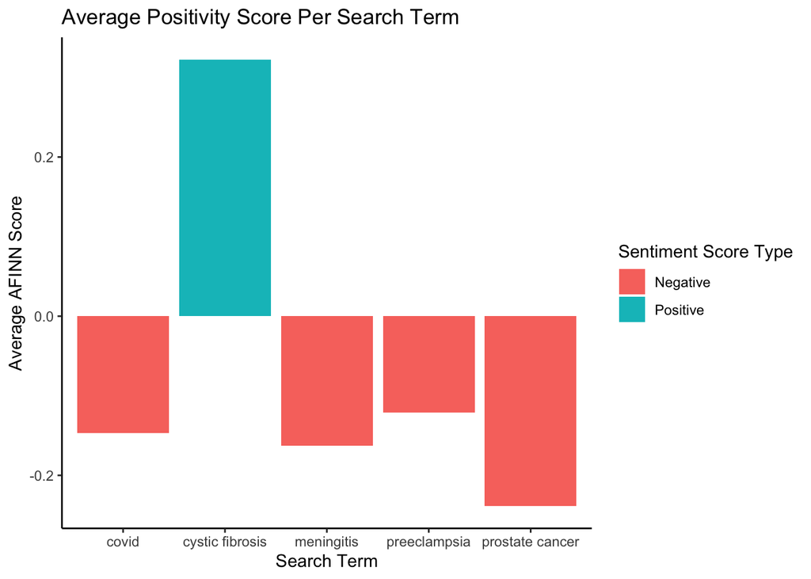

```r
# Visualization
act <- act %>%
  mutate(type = ifelse(avg_term >= 0, "Positive", "Negative"))

act %>%
  ggplot(aes(x = term, y = avg_term)) +
  geom_col(aes(fill = type)) +
  labs(title = "Average Positivity Score Per Search Term",
       x = "Search Term",
       y = "Average AFINN Score",
       fill = "Sentiment Score Type") +
  theme_classic()
```

As we can see, every search term averages an overall negative AFINN score except for cystic fibrosis. While none of these have a particularly high or low score in relation to the scale, prostate cancer has the lowest score while cystic fibrosis has the highest positive sentiment score.

This is interesting because the top feeling in the NRC lexicon for covid and preclampsia are also positive, but we can see that the AFINN lexicon scores them very differently.